# Newton’s method and Scoring

## 1. Maximizing likelihood functions using Newton’s method (1-dim.)

$X_1,\ldots,X_n$을 어떤 모집단으로부터의 랜덤샘플이라 하고, $f(x;\theta)$를 확률밀도(질량)함수라 하자. 여기서 $\theta\in R$는 모수이다.

최대우도추정량(MLE) $\hat\theta$은 다음과 같은 log-likelihood를 최대화하는 값으로 정의된다.

$l(\theta)=\sum_{i=1}^n \log f(X_i;\theta)$

적절한 조건 하에서 MLE를 찾는 것은 다음과 같은 우도방정식을 푸는 것으로 귀결된다.

$l'(\theta) \equiv \frac{\partial l(\theta)}{\partial \theta} = 0$

따라서, 우도방정식의 해를 구하기 위한 Newton’s algorithm은 다음과 같이 표현된다.

$\theta^{n} = \theta^{n-1} - \frac{l'(\theta^{n-1})}{l''(\theta^{n-1})}$

#### 1.1 Observed vs expected information

피셔정보행렬(Fisher information matrix)의 정의를 떠올려 보아라.

$I(\theta)=E\left( - \frac{\partial^2 l(\theta)}{\partial \theta^2 } \right)$

이 때, $-\frac{\partial^2 l(\theta)}{\partial \theta^2}$를 observed information이라 하고, 그 기대값 $I( \theta)$을 expected (Fisher) information 이라 한다.

- $-\frac{\partial^2 l(\hat\theta)}{\partial \theta^2}$는 양수의 값을 가져야 한다. (why?)
- $-\frac{\partial^2 l(\hat\theta)}{\partial \theta^2}$는 최대값 근처에서 우도함수의 모양(특히, 뾰족한 정도)을 결정한다.
- $-\frac{\partial^2 l(\theta)}{\partial \theta^2}$의 값이 모든 $\theta$에 대하여 양수일 경우 Newton’s method에 의해 생성되는 수열의 MLE로의 수렴성이 안정적이다. 하지만, 경우에 따라 음수인 영역이 존재할 수 있으며 이 경우 알고리즘이 불안정할 수 있다.

#### 1.2 Example

##### 1.2.1 성공확률

$X_1,\ldots,X_n$이 $B(1,p)$로부터의 랜덤샘플일 때, 성공확률 $p$에 대한 MLE를 계산해보자.

$l(p)=\sum_{i=1}^n X_i \log p + (1-X_i) \log(1-p)$ $l'(p)=\sum_{i=1}^n X_i/p - (1-X_i)/(1-p)$ $l''(p)=\sum_{i=1}^n -X_i/p^2 - (1-X_i)/(1-p)^2$

1. $l'(p)=0$으로부터 $\hat p = \sum X_i /n$임을 알 수 있다.
2. Newton’s method에 의해 $p^{n} = p^{n-1} - (\sum_{i=1}^n X_i/p^{n-1} - (1-X_i)/(1-p^{n-1}))/(\sum_{i=1}^n -X_i/(p^{n-1})^2 - (1-X_i)/(1-p^{n-1})^2)$

```r
p <- 0.1
g <- function(x,p){sum(x)/p - (length(x)-sum(x))/(1-p)}
dg <- function(x,p){-sum(x)/p^2 - (length(x)-sum(x))/(1-p)^2}
tol <- 10^{-8}
set.seed(1)
x=rbinom(100,1,0.3)
for (i in 1:100)
  {
  J <- dg(x,p)
  newp <- p - g(x,p)/dg(x,p)
  err <- abs(newp-p)
  print(c(i,p))
  if (err<tol) break
  p<-newp
  }
```

```
## [1] 1.0 0.1
## [1] 2.0000000 0.1744361
## [1] 3.0000000 0.2622224
## [1] 4.0000000 0.3128146
## [1] 5.0000000 0.3199112
## [1] 6.00 0.32
## [1] 7.00 0.32
```

```r
c(newp,sum(x)/length(x))
```

```
## [1] 0.32 0.32
```

```r
g(x,p)
```

```
## [1] 1.278977e-13
```

```r
dg(x,p)
```

```
## [1] -459.5588
```

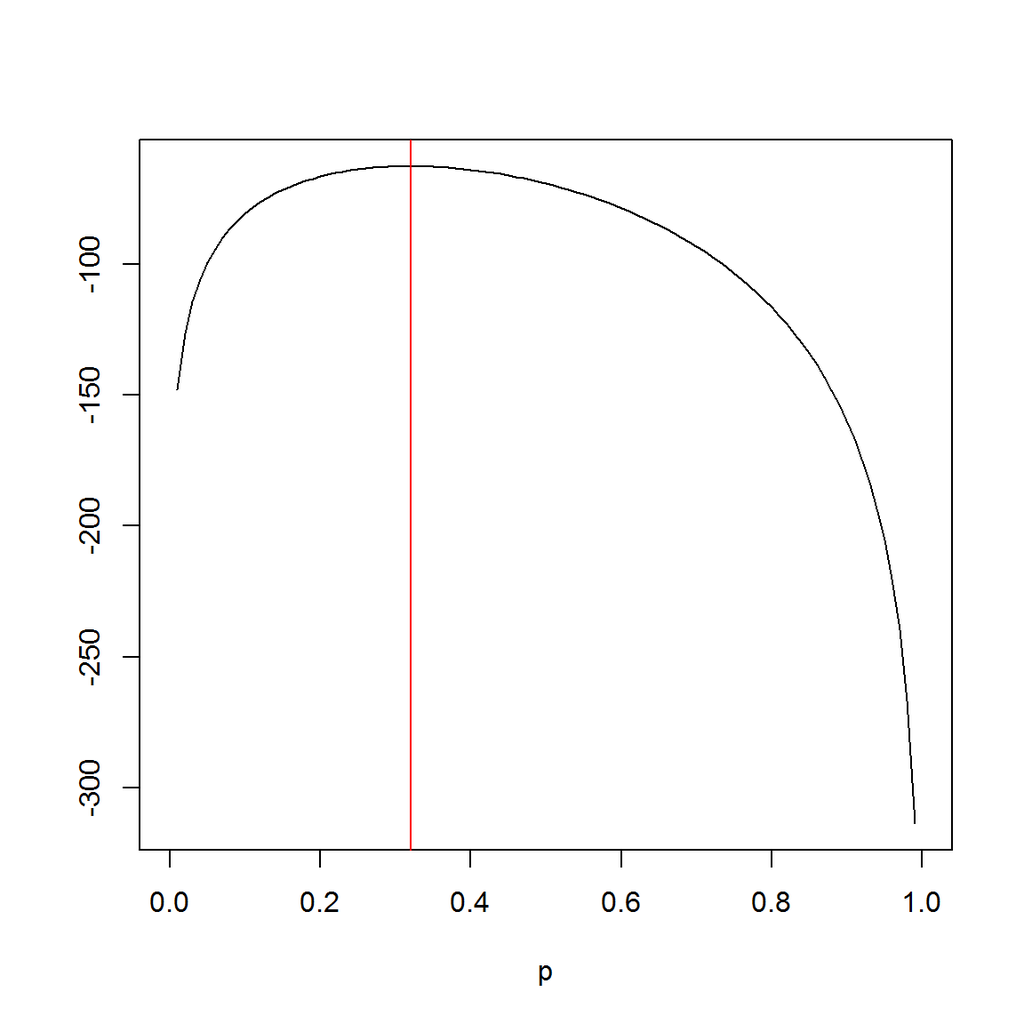

```r
plot(seq(0,1,0.01),sum(x)*log(seq(0,1,0.01)) + (length(x)-sum(x))*log(1-seq(0,1,0.01)),xlab="p",ylab="",type="l")
abline(v=newp,col="red")
```

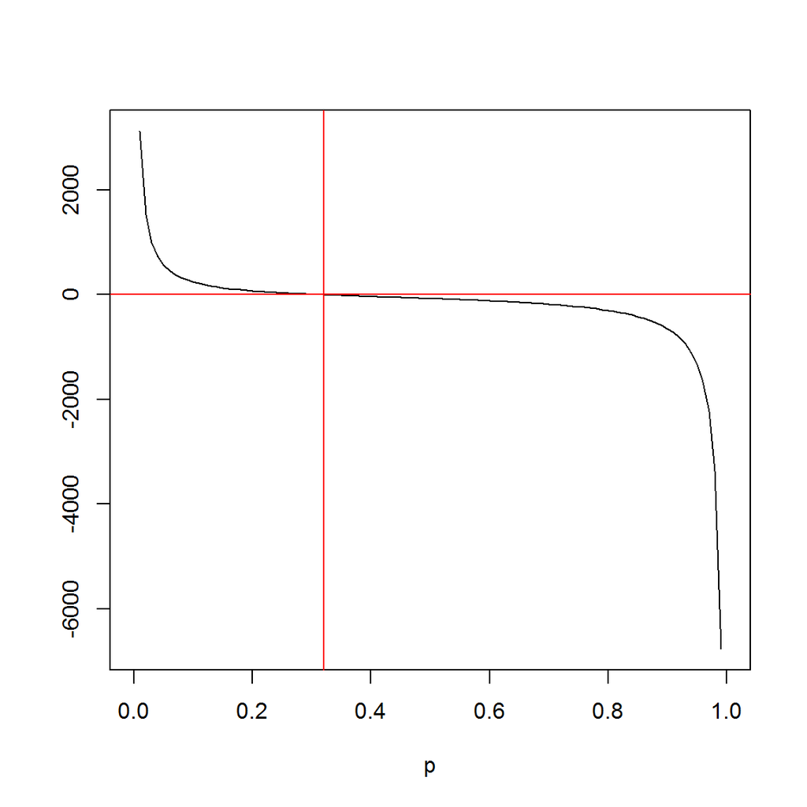

```r
plot(seq(0,1,0.01),g(x,seq(0,1,0.01)),xlab="p",ylab="",type="l")
abline(h=0,v=newp,col="red")
```

##### 1.2.2 로지스틱(logistics) 분포

$X_1,\ldots,X_n$이 다음과 같은 확률분포로부터의 랜덤샘플일 때, 모수 $\theta$에 대한 MLE를 계산해보자.

$f(x;\theta)=\frac{\exp(-(x-\theta))}{(1+\exp(-(x-\theta)))^2},~-\infty<x<\infty.$

$l'(\theta)=n-2\sum_{i=1}^n \frac{\exp(-(X_i-\theta))}{1+\exp(-(X_i-\theta))}$ $l''(\theta)=-2\sum_{i=1}^n \frac{\exp(-(X_i-\theta))}{(1+\exp(-(X_i-\theta)))^2}$

cf) $l''(\theta)<0$.

```r
dl <- function(x,theta){length(x)-2*sum( exp(-x+theta)/(1+exp(-x+theta)))}
ddl <- function(x,theta){-2*sum( exp(-x+theta)/(1+exp(-x+theta))^2)}
tol <- 10^{-8}
set.seed(1)
x=rlogis(100,5,1)
theta <- mean(x)
for (i in 1:100)
  {
  newtheta <- theta - dl(x,theta)/ddl(x,theta)
  err <- abs(newtheta-theta)
  print(c(i,theta))
  if (err<tol) break
  theta<-newtheta
  }
```

```
## [1] 1.000000 5.087336
## [1] 2.000000 5.099729
## [1] 3.000000 5.099729
```

```r
dl(x,theta)
```

```
## [1] -2.842171e-14
```

## 2. Newton’s method

- Example (syetem of equations)

$x^2+y^2-2=0,~x-y-2=0$의 해를 구하여라.

위 문제는 $\left( \begin{array}{c} x^2+y^2-2 \\ x-y-2 \end{array} \right) = \left( \begin{array}{c} 0 \\ 0 \end{array} \right)$ 로 정리 가능함.

앞 장에서 함수가 단변량일 때는 각 지점 $x_i~(i=0,1,\ldots)$에서의 1차 테일러 근사를 이용하여 수열 $x_n$을 생성하였다. 비슷한 방식으로 접근하되 함수가 다변량이므로 다변량함수에 대한 테일러 근사를 이용하여야 한다.

- 이변량함수에 $f(x,y)$ 대한 $(x_0,y_0)$ 근방에서의 1차 테일러 전개

$f(x,y)\approx f(x_0,y_0)+(\frac{\partial f(x_0,y_0)}{\partial x},\frac{\partial f(x_0,y_0)}{\partial y}) (x-x_0,y-y_0)^\top$

cf) $\frac{\partial f(x_0,y_0)}{\partial x}$는 $\frac{\partial f(x,y)}{\partial x}|_{x=x_0,y=y_0}$를 나타냄.

- $f_1(x,y)=x^2+y^2-2,~f_2(x,y)=x-y-2$로 두고 $(1,0)$에서 테일러 근사를 각 함수에 대해서 적용하여 보면
  - $f_1(x,y)\approx -1 + (2,0)(x-1,y-0)^\top = 0$
  - $f_2(x,y)\approx -1 + (1,-1)(x-1,y-0)^\top = 0$

따라서, $\left( \begin{array}{c} 2 & 0 \\ 1 & -1 \end{array} \right) \left( \begin{array}{c} x-1 \\ y-0 \end{array} \right) = - \left( \begin{array}{c} -1 \\ -1 \end{array} \right)~\Rightarrow~ \left( \begin{array}{c} x \\ y \end{array} \right) = \left( \begin{array}{c} 1 \\ 0 \end{array} \right) - \left( \begin{array}{c} 2 & 0 \\ 1 & -1 \end{array} \right)^{-1} \left( \begin{array}{c} -1 \\ -1 \end{array} \right) = \left( \begin{array}{c} 1.5 \\ -0.5 \end{array} \right)$

즉, $x=1.5,y=-0.5$가 한번 업데이트된 해의 근사치이다.

- 이변량의 경우 일반적으로 Newton’s method를 정리하면,

$\left( \begin{array}{c} x_n \\ y_n \end{array} \right)=\left( \begin{array}{c} x_{n-1} \\ y_{n-1} \end{array} \right) - \left( \begin{array}{c} \frac{\partial f_1(x_{n-1},y_{n-1})}{\partial x}&\frac{\partial f_1(x_{n-1},y_{n-1})}{\partial y} \\ \frac{\partial f_2(x_{n-1},y_{n-1})}{\partial x}&\frac{\partial f_2(x_{n-1},y_{n-1})}{\partial y } \end{array} \right)^{-1} \left( \begin{array}{c} f_1(x_{n-1},y_{n-1}) \\ f_2(x_{n-1},y_{n-1}) \end{array} \right)$

위 example의 경우에 적용하면,

$\left( \begin{array}{c} x_n \\ y_n \end{array} \right)=\left( \begin{array}{c} x_{n-1} \\ y_{n-1} \end{array} \right) - \left( \begin{array}{c} 2x_{n-1}&2y_{n-1} \\ 1&-1 \end{array} \right)^{-1} \left( \begin{array}{c} x_{n-1}^2+y_{n-1}^2-2 \\ x_{n-1}-y_{n-1}-2 \end{array} \right)$

```r
z <- c(1,0)
g1 <- function(z){z[1]^2+z[2]^2-2}
g2 <- function(z){z[1]-z[2]-2}
dg11<- function(z){2*z[1]}
dg12<- function(z){2*z[2]}
dg21<- function(z){1}
dg22<- function(z){-1}
tol <- 10^{-4}
for (i in 1:100)
  {
  J <- matrix(c(dg11(z),dg21(z),dg12(z),dg22(z)),2,2)
  newz <- z - solve(J)%*%c(g1(z),g2(z))
  err <- max(abs(newz-z))
  print(c(i,z))
  if (err<tol) break
  z<-newz
  }
```

```
## [1] 1 1 0
## [1]  2.0  1.5 -0.5
## [1]  3.00  1.25 -0.75
## [1]  4.000  1.125 -0.875
## [1]  5.0000  1.0625 -0.9375
## [1]  6.00000  1.03125 -0.96875
## [1]  7.000000  1.015625 -0.984375
## [1]  8.0000000  1.0078125 -0.9921875
## [1]  9.0000000  1.0039062 -0.9960938
## [1] 10.0000000  1.0019531 -0.9980469
## [1] 11.0000000  1.0009766 -0.9990234
## [1] 12.0000000  1.0004883 -0.9995117
## [1] 13.0000000  1.0002441 -0.9997559
## [1] 14.0000000  1.0001221 -0.9998779
```

```r
newz
```

```
##           [,1]
## [1,]  1.000061
## [2,] -0.999939
```

```r
c(g1(newz),g2(newz))
```

```
## [1] 7.450581e-09 0.000000e+00
```

- 일반적으로 $m$개의 서로 다른 $m$-dimensional 함수에 대한 연립방정식을 푸는 Newton’s method

$\mathbf{x}_n = \mathbf{x}_{n-1} - J(\mathbf{x}_{n-1})^{-1}\mathbf{f}(\mathbf{x}_{n-1})$

단,

$\mathbf{x}=(x_1,\ldots,x_m)$, $(\mathbf{f}(\mathbf{x})= (f_1(\mathbf{x}),\ldots,f_m(\mathbf{x})))^\top$, $(J(\mathbf{x_0}))_{ij} = \frac{\partial f_i(\mathbf{x_0})}{\partial x_j}$

- Example

$f(x,y)=x^4+y^4+2x^2y^2$이 언제 최소값을 가지는가?

위 함수의 최소값을 찾는 문제는 $(4x^3+4xy^2,4y^3+4x^2y)=(0,0)$을 푸는 것과 동치임. 그러므로 여기에 Newton’s method를 적용하는 것으로 충분함.

```r
z <- c(1,1)
g1 <- function(z){4*z[1]^3+4*z[1]^2*z[2]}
g2 <- function(z){4*z[2]^3+4*z[2]^2*z[1]}
dg11<- function(z){12*z[1]^2+4*z[2]^2}
dg12<- function(z){8*z[1]*z[2]}
dg21<- function(z){8*z[1]*z[2]}
dg22<- function(z){12*z[2]^2+4*z[1]^2}
tol <- 10^{-4}
for (i in 1:100)
  {
  J <- matrix(c(dg11(z),dg21(z),dg12(z),dg22(z)),2,2)
  newz <- z - solve(J)%*%c(g1(z),g2(z))
  err <- max(abs(newz-z))
  print(c(i,z))
  if (err<tol) break
  z<-newz
  }
```

```
## [1] 1 1 1
## [1] 2.0000000 0.6666667 0.6666667
## [1] 3.0000000 0.4444444 0.4444444
## [1] 4.0000000 0.2962963 0.2962963
## [1] 5.0000000 0.1975309 0.1975309
## [1] 6.0000000 0.1316872 0.1316872
## [1] 7.0000000 0.0877915 0.0877915
## [1] 8.00000000 0.05852766 0.05852766
## [1] 9.00000000 0.03901844 0.03901844
## [1] 10.00000000  0.02601229  0.02601229
## [1] 11.00000000  0.01734153  0.01734153
## [1] 12.00000000  0.01156102  0.01156102
## [1] 13.000000000  0.007707347  0.007707347
## [1] 14.000000000  0.005138231  0.005138231
## [1] 15.000000000  0.003425487  0.003425487
## [1] 16.000000000  0.002283658  0.002283658
## [1] 17.000000000  0.001522439  0.001522439
## [1] 18.000000000  0.001014959  0.001014959
## [1] 1.900000e+01 6.766395e-04 6.766395e-04
## [1] 2.00000e+01 4.51093e-04 4.51093e-04
## [1] 2.100000e+01 3.007287e-04 3.007287e-04
## [1] 2.200000e+01 2.004858e-04 2.004858e-04
```

```r
newz
```

```
##              [,1]
## [1,] 0.0001336572
## [2,] 0.0001336572
```

```r
c(g1(newz),g2(newz))
```

```
## [1] 1.910147e-11 1.910147e-11
```

cf) 업데이트 되는 알고리즘을 자세하게 써서 정리하여 보아라.

## 3. Maximizing likelihood functions Using Newton’s method ($k$-dim.)

$X_1,\ldots,X_n$을 어떤 모집단으로부터의 랜덤샘플이라 하고, $f(x;\theta)$를 확률밀도(질량)함수라 하자. 여기서 $\theta=(\theta_1,\ldots,\theta_k)\in R^k$는 모수이다.

최대우도추정량(MLE) $\hat\theta$은 다음과 같은 log-likelihood를 최대화하는 값으로 정의된다.

$l(\theta)=\sum_{i=1}^n \log f(X_i;\theta)$

적절한 조건 하에서 MLE를 찾는 것은 다음과 같은 우도방정식을 푸는 것으로 귀결된다.

$d l(\theta) \equiv \frac{\partial l(\theta)}{\partial \theta} = 0$

$l(\theta)$의 1차, 2차 (편)미분함수들을 다음과 같이 정의하면,

- $(dl(\theta))_j=\frac{\partial l(\theta)}{\partial \theta_j}~,j=1,\ldots,k$
- $(d^2l(\theta))_{jk} = \frac{\partial^2 l(\theta)}{\partial \theta_i \partial \theta_j}~,i,j=1,\ldots,k$

우도방정식의 해를 구하기 위한 Newton’s algorithm은 다음과 같이 표현된다.

$\theta^{n} = \theta^{n-1} - d^2l(\theta^{n-1})^{-1}dl(\theta^{n-1})$

여기서 $dl(\theta)$를 $l(\theta)$의 gradient vector, $d^2l(\theta)$를 Hessian matrix 라 한다.

#### 3.1 Observed vs expected information

피셔정보행렬(Fisher information matrix)의 정의를 떠올려 보아라.

$I(\theta)=E\left( - \frac{\partial^2 l(\theta)}{\partial \theta^2 } \right)=Var\left( \frac{\partial l(\theta)}{\partial \theta } \right)$

여기서 $\frac{\partial^2 l(\theta)}{\partial \theta^2 }=d^2l(\theta)$는 Hessian matrix이다. 즉,

$I(\theta)=E(-d^2l(\theta))$

임을 알 수 있다. 이 때, $-d^2l(\theta)$를 observed information이라 하고, 그 기대값을 expected (Fisher) information 이라 한다.

- $-d^2l(\hat\theta)$는 최대값 근처에서 우도함수의 모양(특히, 뾰족한 정도)을 결정한다.
- $-d^2(\theta)$의 값이 모든 $\theta$에 대하여 양정치행렬(positive definite)인 경우 Newton’s method에 의해 생성되는 수열의 MLE로의 수렴성이 안정적이다. 하지만, 경우에 따라 그렇지 않을 수 있으며 이 경우 알고리즘이 불안정할 수 있다.

#### 3.2 Example

$X_1,\ldots,X_n$이 $N(\mu,\sigma^2)$로부터의 랜덤샘플일 때, $\theta=(\mu,\sigma^2)\in R\times R^+$에 대한 MLE.

$l(\theta) = -n \log(\sigma) - \sum_{i=1}^n ((x_i - \mu)^2/2\sigma^2 + constant.)$

$dl(\theta) = \left( \begin{array}{c} \sum_{i=1}^n (x_i - \mu)/\sigma^2 \\ \sum_{i=1}^n (x_i - \mu)^2/2\sigma^4 - n/2\sigma^2 \end{array} \right)$

$d^2l(\theta) = \left( \begin{array}{cc} -n/\sigma^2 & -\sum_{i=1}^n (x_i - \mu)/\sigma^4 \\ -\sum_{i=1}^n (x_i - \mu)/\sigma^4 & - \sum_{i=1}^n (x_i - \mu)^2/\sigma^6 + n/2\sigma^4 \end{array} \right)$

```r
theta <- c(1,1)
dl1 <- function(x,m,s){sum(x-m)/s}
dl2 <- function(x,m,s){sum((x-m)^2)/(2*s^2)-length(x)/(2*s)}
ddl11<- function(x,m,s){-length(x)/s}
ddl12<- function(x,m,s){-sum(x-m)/(s^2)}
ddl21<- function(x,m,s){-sum(x-m)/(s^2)}
ddl22<- function(x,m,s){-sum((x-m)^2)/(s^3)+length(x)/(2*s^2)}
tol <- 10^{-8}
set.seed(1)
x <- rnorm(100,2,3)
for (i in 1:100)
  {
  ddl <- matrix(c(ddl11(x,theta[1],theta[2]),ddl21(x,theta[1],theta[2]),ddl12(x,theta[1],theta[2]),ddl22(x,theta[1],theta[2])),2,2)
  newtheta <- theta - solve(ddl)%*%c(dl1(x,theta[1],theta[2]),dl2(x,theta[1],theta[2]))
  err <- sum((newtheta-theta)^2)
  print(c(i,theta))
  if (err<tol) break
  theta<-newtheta
  }
```

```
## [1] 1 1 1
## [1] 2.000000 1.887478 1.331045
## [1] 3.000000 2.135969 1.908983
## [1] 4.000000 2.246471 2.711758
## [1] 5.000000 2.295932 3.750934
## [1] 6.000000 2.316724 4.964009
## [1] 7.000000 2.324314 6.136989
## [1] 8.000000 2.326362 6.919990
## [1] 9.000000 2.326651 7.168948
## [1] 10.000000  2.326662  7.188147
## [1] 11.000000  2.326662  7.188250
```

```r
newtheta
```

```
##          [,1]
## [1,] 2.326662
## [2,] 7.188250
```

## 4. Scoring method

앞에서 이야기한 바대로 Newton’s method는 빠른 수렴속도를 보장하는 대신 알고리즘의 불안정성 문제가 발생하는 경우가 빈번하다. 또한, Hessian matrix를 매 iteration step마다 계산하고 inverse를 취하여야 하는데 이 계산과정에 매우 큰 자원(혹은 시간)이 소요되는 경우가 있다. 이러한 단점을 보완하기 위하여 제안된 방법이 Scoring method이다. 이 방법은 기본적인 알고리즘의 형태는 유지하되 observed information인 $-d^2l(\theta)$(- Hessian matrix)를 그 기대값인 expected information $I(\theta)$(피셔정보행렬)로 대체하는 것이다.

$\theta^{n} = \theta^{n-1} + I(\theta^{n-1})^{-1}dl(\theta^{n-1})$

- $I(\theta)$는 $-d^2l(\theta)$에 비해 계산이 간단한 경우가 많다.
- $I(\theta)$는 언제나 양수의 값(모수의 차원이 1인 경우)을 가지거나 양정치행렬(positive (semi-)definite matrix)이다. (why?)

위와 같은 이유에 의해 알고리즘이 Newton’s method에 비해 안정화되는 경향이 있으며, 계산량도 더 적어진다.

- cf1) 어떤 경우에는 Newton’s method와 scoring method가 동일하다.
- cf2) 피셔정보행렬로 대체하는 것이 가장 일반적이나, 다른 방법들도 존재한다. (예를 들어 항등행렬 $I$로 대체)
- cf3) 피셔정보행렬의 역행렬(을 true parameter에서 계산한 값)이 MLE의 점근적분산인 것으로 알려져 있고, Scoring method는 이 값을 자동으로 제공한다.

#### 4.1 성공확률 (revisited)

$X_1,\ldots,X_n$이 $B(1,p)$로부터의 랜덤샘플일 때, 성공확률 $p$에 대한 MLE.

$l''(p)=\sum_{i=1}^n -X_i/p^2 - (1-X_i)/(1-p)^2$ $E(l''(p))=-n/(p(1-p))$

```r
p <- 0.1
g <- function(x,p){sum(x)/p - (length(x)-sum(x))/(1-p)}
dg <- function(x,p){-length(x)/(p*(1-p))}
tol <- 10^{-8}
set.seed(1)
x=rbinom(100,1,0.3)
for (i in 1:100)
  {
  J <- dg(x,p)
  newp <- p - g(x,p)/dg(x,p)
  err <- abs(newp-p)
  print(c(i,p))
  if (err<tol) break
  p<-newp
  }
```

```
## [1] 1.0 0.1
## [1] 2.00 0.32
```

```r
c(newp,sum(x)/length(x))
```

```
## [1] 0.32 0.32
```

cf) 알고리즘을 구체적으로 작성하여 보아라.

#### 4.2 로지스틱(logistics) 분포 (revisited)

$X_1,\ldots,X_n$이 다음과 같은 확률분포로부터의 랜덤샘플일 때, 모수 $\theta$에 대한 MLE를 계산해보자.

$f(x;\theta)=\frac{\exp(-(x-\theta))}{(1+\exp(-(x-\theta)))^2},~-\infty<x<\infty.$

$l''(\theta)=-2\sum_{i=1}^n \frac{\exp(-(X_i-\theta))}{(1+\exp(-(X_i-\theta)))^2}$ $E(l''(\theta))=-n/3$

```r
dl <- function(x,theta){length(x)-2*sum( exp(-x+theta)/(1+exp(-x+theta)))}
ddl <- function(x,theta){-2*sum( exp(-x+theta)/(1+exp(-x+theta))^2)}
tol <- 10^{-8}
set.seed(1)
x=rlogis(100,5,1)
theta <- mean(x)
for (i in 1:100)
  {
  newtheta <- theta - dl(x,theta)/(-length(x)/3)
  err <- abs(newtheta-theta)
  print(c(i,theta))
  if (err<tol) break
  theta<-newtheta
  }
```

```
## [1] 1.000000 5.087336
## [1] 2.000000 5.100649
## [1] 3.00000 5.09966
## [1] 4.000000 5.099734
## [1] 5.000000 5.099728
## [1] 6.000000 5.099729
## [1] 7.000000 5.099729
```

```r
dl(x,theta)
```

```
## [1] 7.471326e-08
```

cf) expected information의 계산이 너무 복잡한 경우 Scoring method의 적용이 더 어려운 경우도 있다.

#### 4.3 정규분포 (revisited)

$d^2l(\theta) = \left( \begin{array}{cc} -n/\sigma^2 & -\sum_{i=1}^n (x_i - \mu)/\sigma^4 \\ -\sum_{i=1}^n (x_i - \mu)/\sigma^4 & - \sum_{i=1}^n (x_i - \mu)^2/\sigma^6 + n/2\sigma^4 \end{array} \right)$

으로부터

$I(\theta)=E(-d^2l(\theta)) = \left( \begin{array}{cc} n/\sigma^2 & 0 \\ 0 & n/2\sigma^4 \end{array} \right)$

```r
theta <- c(1,1)
dl1 <- function(x,m,s){sum(x-m)/s}
dl2 <- function(x,m,s){sum((x-m)^2)/(2*s^2)-length(x)/(2*s)}
ddl11<- function(x,m,s){length(x)/s}
ddl22<- function(x,m,s){length(x)/(2*s^2)}
tol <- 10^{-8}
set.seed(1)
x <- rnorm(100,2,3)
for (i in 1:100)
  {
  ddl <- matrix(c(ddl11(x,theta[1],theta[2]),0,0,ddl22(x,theta[1],theta[2])),2,2)
  newtheta <- theta + solve(ddl)%*%c(dl1(x,theta[1],theta[2]),dl2(x,theta[1],theta[2]))
  err <- sum((newtheta-theta)^2)
  print(c(i,theta))
  if (err<tol) break
  theta<-newtheta
  }
```

```
## [1] 1 1 1
## [1] 2.000000 2.326662 8.948283
## [1] 3.000000 2.326662 7.188250
```

```r
newtheta
```

```
##          [,1]
## [1,] 2.326662
## [2,] 7.188250
```

## 5. Exercise

1. Weibull distribution

$f(x;\alpha,\beta)=\alpha\beta x^{\beta-1}\exp(-\alpha x^\beta),~x>0,\alpha,\beta>0.$

2. Cauchy distribution

$f(x;\theta)=1/(\pi (1+(x-\theta)^2)),~x\in R,\theta \in R.$

3. Gamma distribution

$f(x;\alpha,\lambda) = (\lambda^\alpha /\Gamma(\alpha) ) x^{\alpha-1}\exp(-\lambda x),~x>0, \alpha,\lambda>0.$

4. Geometric distribution (with re-parametrization)

$f(x;\beta) = \frac{\beta^x}{(1+\beta)^{x+1}},~x=0,1,\ldots,~\beta>0$

## 6. Nonlinear regression

#### 6.1 Normally distributed errors

$X_1,\ldots,X_n$이 $N(\mu_i(\phi),\sigma^2/w_i)$로부터의 랜덤샘플이라고 하자. 추정모수는 $\phi,\sigma^2\in R^m\times R^+$이고 $w_i$는 알려져 있는 상수일 때, 우도함수는 다음과 같이 표현된다.

$l(\phi,\sigma^2) = - \frac{n}{2}\log \sigma^2 - \frac{1}{2\sigma^2} \sum_{i=1}^n w_i(X_i-\mu_i(\phi))^2$

따라서,

$dl(\phi,\sigma^2) = \left( \begin{array}{c} \frac{1}{\sigma^2}\sum_{i=1}^n w_i(X_i-\mu_i(\phi))d\mu_i(\phi) \\ - \frac{n}{2\sigma^2} + \frac{1}{2\sigma^4}\sum_{i=1}^n w_i(X_i-\mu_i(\phi))^2 \end{array} \right)$

$d^2l(\phi,\sigma^2) = \left( \begin{array}{cc} -\frac{1}{\sigma^2}\sum_{i=1}^n w_i d\mu_i(\phi)d\mu_i(\phi)^\top + \frac{1}{\sigma^2}\sum_{i=1}^n w_i(X_i-\mu_i(\phi))d^2\mu_i(\phi)& -\frac{1}{\sigma^4}\sum_{i=1}^n w_i(X_i-\mu_i(\phi))d\mu_i(\phi) \\ -\frac{1}{\sigma^4}\sum_{i=1}^n w_i(X_i-\mu_i(\phi))d\mu_i(\phi) & \frac{n}{2\sigma^4} - \frac{1}{\sigma^6}\sum_{i=1}^n w_i(X_i-\mu_i(\phi))^2 \end{array} \right)$

$I(\theta)=E(-d^2l(\phi,\sigma^2)) = \left( \begin{array}{cc} \frac{1}{\sigma^2}\sum_{i=1}^n w_id\mu_i(\phi)d\mu_i(\phi)^\top & 0 \\ 0 & \frac{n}{2\sigma^4} \end{array} \right)$

그러므로, Scoring method를 적용하면,

$\phi^{n}=\phi^{n-1} + \left[ \sum_{i=1}^n w_id\mu_i(\phi)d\mu_i(\phi)^\top \right]^{-1}\sum_{i=1}^n w_i(X_i-\mu_i(\phi))d\mu_i(\phi)$

$(\sigma^2)^{n}=\frac{1}{n} \sum_{i=1}^n w_i(X_i-\mu_i(\phi^{n-1}))^2$

이때, $\phi$에 대한 업데이트 알고리즘을 Gauss-Newton 알고리즘이라고 부른다.

위 알고리즘에서 특이한 점은 $\phi$의 업데이트에 $\sigma^2$은 전혀 관여하지 않는다는 것이다. 그리고, $\sigma^2$에 대한 추정량은 $\phi$의 최종 업데이트 값을 위에 대입함으로써 얻어진다.

#### 6.2 Least squares

$X_1,\ldots,X_n$이 평균이 $\mu_i(\phi)$인 분포로부터의 랜덤샘플이라고 할 때, 제곱합을 다음과 같이 정의.

$S(\phi) = \sum_{i=1}^n w_i(X_i-\mu_i(\phi))^2$

$S(\phi)$를 최소로 하는 $\phi$를 Newton’s method에 의해 찾으면,

$\phi^{n}=\phi^{n-1} + \left[ \sum_{i=1}^n w_id\mu_i(\phi)d\mu_i(\phi)^\top - \sum_{i=1}^n w_i(X_i-\mu_i(\phi))d^2\mu_i(\phi)\right]^{-1}\sum_{i=1}^n w_i(X_i-\mu_i(\phi))d\mu_i(\phi).$

Hessian에서 $- \sum_{i=1}^n w_i(X_i-\mu_i(\phi))d^2\mu_i(\phi)$부분은 종종 생략되고 ($\mu_i(\phi)$가 선형함수에 가깝거나 오차를 나타내는 $(X_i-\mu_i(\phi))$가 충분히 작으면 생략하는 것에 큰 무리가 없음.) 첫번째 term만 남기기도 한다. 이렇게 하면, 6.1의 Gauss-Newton 알고리즘과 같아진다. 또한, 그렇게 되면 근사적인 Hessian matrix가 양정치행렬이 되어 알고리즘이 안정화된다 (MLE를 얻기 위해 scoring method를 슬 때 나타나는 장점과 같다.). 이렇게 구한 추정량을 $\hat\phi$라 하면,

1. $\hat\phi$의 점근적 분포는 $N(\phi,\sigma^2(J^\top J)^{-1})$, $(J)_{ij}=\partial\mu_i/\partial\phi_j$.
2. $\sigma^2$은 $S(\hat\phi)/(n-m)$으로 추정될 수 있다.
3. $J$는 $J(\hat\phi)$에 의해 추정될 수 있다.
- Exponential population model

$X_i = \phi_1 \exp(\phi_2 z_i) + \epsilon_i,~~\epsilon_i\sim N(0,7^2)$

where $\phi_1=3,\phi_2=0.3$.

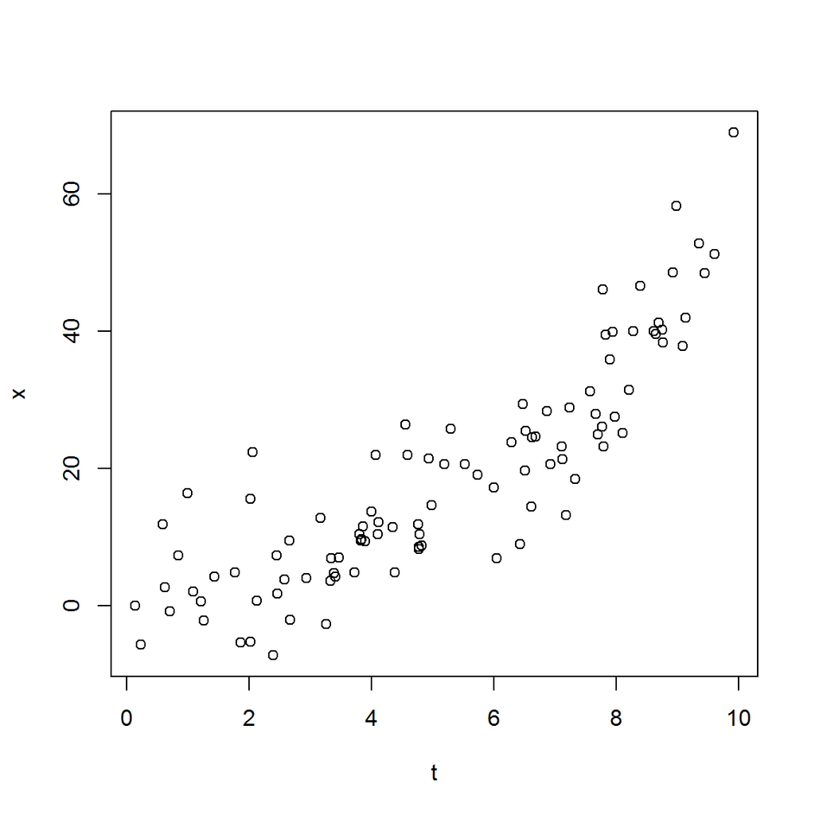

```r
ddmu11 <- function(t,phi){sum(exp(2*phi[2]*t))}
ddmu12 <- ddmu21 <- function(t,phi){sum( phi[1]*t*exp(2*phi[2]*t) )}
ddmu22 <- function(t,phi){sum( phi[1]^2*t^2*exp(2*phi[2]*t) )}
dmu1 <- function(x,t,phi){sum( (x-phi[1]*exp(phi[2]*t)) * exp(phi[2]*t))}
dmu2 <- function(x,t,phi){sum( (x-phi[1]*exp(phi[2]*t)) * phi[1]*t*exp(phi[2]*t))}
tol <- 10^{-8}
set.seed(1)
t <- runif(100,0,10)
phi <- c(1,1)
x <- 3*exp(0.3*t) + rnorm(100,0,7)
plot(t,x)
```

```r
for (i in 1:100)
  {
  dmu <-c(dmu1(x,t,phi),dmu2(x,t,phi))
  ddmu <- matrix(c(ddmu11(t,phi),ddmu12(t,phi),ddmu21(t,phi),ddmu22(t,phi)),2,2)
  newphi <- phi + solve(ddmu)%*%dmu
  err <- max(abs(newphi-phi))
  print(c(i,phi))
  if (err<tol) break
  phi<-newphi
  }
```

```
## [1] 1 1 1
## [1] 2.00000000 0.04798841 0.99538910
## [1] 3.00000000 0.04980944 0.89570852
## [1] 4.0000000 0.1099059 0.6865561
## [1] 5.0000000 0.5143744 0.2673006
## [1] 6.0000000 2.5716430 0.6001233
## [1] 7.0000000 0.9039368 0.5702227
## [1] 8.0000000 1.0817402 0.4711057
## [1] 9.0000000 1.8118112 0.3528836
## [1] 10.0000000  2.6320627  0.3083142
## [1] 11.000000  2.717935  0.313716
## [1] 12.0000000  2.7193316  0.3133709
## [1] 13.0000000  2.7193521  0.3133697
## [1] 14.0000000  2.7193522  0.3133697
```

```r
sigma <- mean((x-phi[1]*exp(phi[2]*t))^2)
c(phi,sigma)
```

```
## [1]  2.7193522  0.3133697 42.5948903
```

```r
ddmu<-matrix(c(ddmu11(t,phi),ddmu12(t,phi),ddmu21(t,phi),ddmu22(t,phi)),2,2)
sigma*solve(ddmu)   # covariance matrix of hatphi
```

```
##              [,1]          [,2]
## [1,]  0.171054271 -0.0074948676
## [2,] -0.007494868  0.0003393297
```

```r
2*sigma^2/length(x)  # variance of sigma^2
```

```
## [1] 36.28649
```

## 7. Generalized linear model (일반화선형모형)

선형회귀모형은 추정과 해석이 매우 간단하고 직관적이어서 매우 널리 사용되어 왔다. 하지만, 어떤 경우에는 선형회귀모형이 한계를 가질 때가 있다. 그것은

1. 반응변수의 범위가 제한되어 있을 때 (예) 사망여부, 수상횟수)
2. 반응변수의 분산이 평균에 의존하여 변할 때

등이다. 일반화선형모형(GLM)은 이러한 한계를 극복 혹은 보완할 수 있는 모형이다.

#### 7.1 Exponential family (지수족)

통계분석을 위해 유용한 많은 분포가 지수족이라고 하는 분포족으로 일반화할 수 있음을 알고 있을 것이다. 확률밀도(질량)함수가 다음과 같은 형태를 가질 때 지수족에 속한다 한다.

$f(x;\theta)=g(x)\exp(\beta(\theta)+h(x)^\top \gamma(\theta)).$

예1. $g(x)=1, \beta(\theta)=-\log(\theta), h(x)=x, \gamma(\theta)=-1/\theta$ -> 지수분포

예2. $g(x)=1/x!, \beta(\theta)=-\theta, h(x)=x, \gamma(\theta)=\log\theta$ -> Poisson 분포

지수족의 경우 로그우도함수에 대하여 gradient vector(score function)와 expected information matrix는 각각 다음과 같이 계산된다.

$dl(\theta)=(h(x)-\mu(\theta))^\top\Sigma(\theta)^{-1}d\mu(\theta)$

$d^2l(\theta)=(h(x)-\mu(\theta))^\top\Sigma(\theta)^{-1}d\mu(\theta)$

$I(\theta)=d\mu(\theta)^\top\Sigma(\theta)^{-1}d\mu(\theta)$

단, 여기서 $\mu(\theta)=E(h(X))$, $\Sigma(\theta)=Var(h(X))$ 이다.

cf1) $\gamma(\theta)$가 선형함수면, observed information과 expected information이 일치한다. 즉, Newton’s method와 Scoring method가 일치한다.

cf2) $X_1,\ldots,X_n$을 독립표본이라 할 때, score function은 $dl(\theta)=\sum_{i=1}^n (h(X_i)-\mu_i(\theta))^\top\Sigma_i(\theta)^{-1}d\mu_i(\theta)$

- Binomial model

$X\sim B(n,p)$

이는 $g(x)=\binom{n}{x},~h(x)=x,~\gamma(\theta)=\log p/(1-p)$ and $\beta(\theta)=n\log(1-p)$인 지수족이다. 또한,

$\mu(\theta)=np,~d\mu(\theta)=ndp,~\Sigma(\theta)=np(1-p).$

그러므로,

$dl(\theta)=\frac{(X_i-np(\theta)}{p(\theta)(1-p(\theta))}dp(\theta)$

$I(\theta)=\frac{ndp(\theta)dp(\theta)^\top}{p(\theta)(1-p(\theta))}$

- Poisson model

$X\sim Poisson(\lambda)$

이는 $g(x)=1/x!,~h(x)=x,~\gamma(\theta)=\log \lambda$ and $\beta(\theta)=-\lambda$인 지수족이다. 또한,

$\mu(\theta)=\lambda,~d\mu(\theta)=d\lambda,~\Sigma(\theta)=\lambda.$

그러므로,

$dl(\theta)=\frac{(X-\lambda)}{\lambda}d\lambda(\theta)$

$I(\theta)=\frac{d\lambda(\theta) d\lambda(\theta)^\top}{\lambda(\theta)}$

- Multinomial model

$X=(X_1,\ldots,X_m) \sim Multi(n,p_1(\theta),\ldots,p_m(\theta))$

$E(X)=p(\theta)=(p_1(\theta),\ldots,p_m(\theta))^\top,~Var(X)=n[diag(p(\theta))-p(\theta)p(\theta)^\top]$

따라서,

$dl(p)=\sum_{i=1}^m \frac{X_i}{p_i(\theta)}dp_i(\theta)$

$I(p)=\sum_{i=1}^m \frac{n}{p_i}dp_i(\theta)dp_i(\theta)^\top.$

cf) multinomial 분포의 공분산행렬은 역행렬이 존재하지 않는다. 다만, 일반화역행렬(generalized inverse)를 이용하여 계산하면, 위와 같은 결과를 얻을 수 있다. (참고문헌 Table 11.1 (개정판 Table 14.1))

- Example : Allele frequency estimation

혈액형을 결정하는 유전자는 A, B, O 세 가지 타입으로 알려져 있으며, 이들의 조합에 의해 실제로는 A(AA/AO), B(BB,BO), O(OO), AB(AB) 네 가지의 형질로 나타난다. 만약 A,B 유전자의 비율을 $\theta=(p_A,p_B)$라 하면, 각 형질이 나타날 확률은

(1)A : $P_A^2+2P_A(1-P_A-P_B)$

(2)B : $P_B^2+2P_B(1-P_A-P_B)$

(3)O : $(1-P_A-P_B)^2$

(4)AB : $2P_AP_B$

가 될 것이다. 즉, $X=(n_A,n_B,n_O,n_{AB})^\top$를 $n$명의 사람에 대하여 각각의 형질이 나타난 것을 count한 것, $p(\theta)$를 위 (1)~(4)에 나타난 각 형질의 발생확률이라 하면, $X \sim multi(n,p(\theta))$라 할 수 있다.

실제 십이지장 궤양 환자 521명을 조사한 결과, 각 혈액형이 A:186, B:38, O:284, AB:13 으로 관측되었다고 할 때, $\theta$의 MLE를 계산하여 보자.

$dp_1(\theta) = (2(1-P_A-P_B),-2P_A)^\top$ $dp_2(\theta) = (-2P_B,2(1-P_A-P_B))^\top$ $dp_3(\theta) = (-2(1-P_A-P_B),-2(1-P_A-P_B))^\top$ $dp_4(\theta) = (2P_B,2P_A)^\top$

```r
theta<-c(0.3,0.2)
p1<-function(theta){theta[1]*(2-theta[1]-2*theta[2])}
p2<-function(theta){theta[2]*(2-theta[2]-2*theta[1])}
p3<-function(theta){(1-theta[1]-theta[2])^2}
p4<-function(theta){2*theta[1]*theta[2]}
dp1<-function(theta){ c(2*(1-theta[1]-theta[2]),-2*theta[1])  }
dp2<-function(theta){ c(-2*theta[2],2*(1-theta[1]-theta[2]))  }
dp3<-function(theta){ c(-2*(1-theta[1]-theta[2]),-2*(1-theta[1]-theta[2]))  }
dp4<-function(theta){ c(2*theta[2],2*theta[1])  }
dl <- function(t,theta){ cbind(dp1(theta),dp2(theta),dp3(theta),dp4(theta))%*%(t/c(p1(theta),p2(theta),p3(theta),p4(theta)))  }
I <- function(t,theta){ cbind(dp1(theta),dp2(theta),dp3(theta),dp4(theta))%*%diag(sum(t)/c(p1(theta),p2(theta),p3(theta),p4(theta)))%*%t(cbind(dp1(theta),dp2(theta),dp3(theta),dp4(theta))) }
tol <- 10^{-8}
set.seed(1)
t <- c(186,38,284,13)
for (i in 1:100)
  {
  newtheta <- theta + solve(I(t,theta))%*%dl(t,theta)
  err <- max(abs(newtheta-theta))
  print(c(i,theta))
  if (err<tol) break
  theta<-newtheta
  }
```

```
## [1] 1.0 0.3 0.2
## [1] 2.0000000 0.2025672 0.0321977
## [1] 3.00000000 0.21350164 0.04999542
## [1] 4.0000000 0.2135911 0.0501455
## [1] 5.00000000 0.21359094 0.05014533
```

```r
c(theta,1-sum(theta))
```

```
## [1] 0.21359094 0.05014533 0.73626373
```

```r
ACOV=solve(I(t,theta))   # covariance matrix of hattheta
sqrt(c(ACOV[1,1],ACOV[2,2],ACOV[1,1]+ACOV[2,2]+2*ACOV[1,2]))  # asymptotic standard deviation of estimates
```

```
## [1] 0.013525296 0.006849005 0.014469224
```

#### 7.2 GLM

$X_1,\ldots,X_n$이 지수족에 포함된 분포로부터의 임의표본이고, $h(X)=X$일 때 $X$의 평균 $E(X)=\mu(\theta)$라 하자. 단조함수 $q$에 의하여 평균과 또다른 변수의 선형결합을 다음과 같이 모형화한다면,

$E(X_i)=\mu_i(\theta)=q(z_i^\top\theta).$

score function과 expected information은 다음과 같이 주어진다.

$dl(\theta)=\sum_{i=1}^n \frac{X_i-\mu_i(\theta)}{\sigma_i(\theta)^2}q'(z_i^\top\theta)z_i.$

$I(\theta)=\sum_{i=1}^n \frac{q'(z_i^\top\theta)^2}{\sigma_i(\theta)^2}z_iz_i^\top.$

여기서, $q$의 역함수 $q^{-1}=g$를 연결함수(link function)이라 한다. 즉, GLM은

$g(E(X))=z^\top\theta$

와 같이 평균의 적절한 변환을 선형으로 모형화하는 것이다. 만약, $g$가 항등함수인 경우 이 모형은 우리가 잘 알고 있는 선형회귀모형이 된다.

연결함수는 평균이 가지게 되는 범위를 적절하게 조정해 주는 역할을 주로 한다. 연결함수를 어떻게 지정하느냐에 따라 $\theta$의 추정량의 성질이 달라질 수 있으며, 특히 수치적으로 해를 구하는 알고리즘의 성질에도 영향을 미치게 된다.

$\theta=E(X)$이면, $\gamma(\cdot)$을 정준연결함수(canonical link function)이라고 한다. 이 경우 Newton’s method와 Scoring method가 일치하게 된다. (Why?)

- Logistic regression

$X_1,\ldots,X_n \sim Bernoulli(p_i),~indep$일 때, 설명변수 $z_i$에 대하여 다음과 같이 모형화하면,

$logit(p_i)=\log \frac{p_i}{1-p_i} = z_i^\top\theta.$

$p_i=\mu_i(\theta)=\exp(z_i^\top\theta)/(1+\exp(z_i^\top\theta))$, $q(t)=\exp(t)/(1+\exp(t))$, $\sigma_i^2=p_i(1-p_i)$

$dl(\theta)=\sum_{i=1}^n \frac{X_i-p_i(\theta)}{p_i(\theta)(1-p_i(\theta))}q'(z_i^\top) z_i.$ $~~~~~=\sum_{i=1}^n (X_i - \exp(z_i^\top\theta)/(1+\exp(z_i^\top\theta))) z_i.$

$I(\theta)=\sum_{i=1}^n \frac{\exp(z_i^\top\theta)}{(1+\exp(z_i^\top\theta))^2}z_iz_i^\top.$

cf) 연결함수 $g=q^{-1}=\Phi^{-1}(\cdot)$으로 하는 경우 Probit 모형이라 부른다. 또한 $g=q^{-1}=\log(-\log(1-\cdot))$으로 하기도 한다. 정준연결함수는 Logit 함수이다.

- Poisson regression

$X_1,\ldots,X_n \sim Poisson(\lambda_i),~indep$일 때, 설명변수 $z_i$에 대하여 다음과 같이 모형화하면,

$\log(\lambda_i) = z_i^\top\theta.$

$\lambda_i=\mu_i(\theta)=\exp(z_i^\top\theta)$, $q(t)=\exp(t)$, $\sigma_i^2=\lambda_i$

$dl(\theta)=\sum_{i=1}^n \frac{X_i-\exp(z_i^\top\theta)}{\exp(z_i^\top\theta)}q'(z_i^\top) z_i.$ $~~~~~=\sum_{i=1}^n (X_i - \exp(z_i^\top\theta)) z_i.$

$I(\theta)=\sum_{i=1}^n \exp(z_i^\top\theta) z_iz_i^\top.$

cf) 정준연결함수는 Log 함수이다.

#### 7.3 Example

AIDS data from Australia during 1983-1986

```r
z <- 1:14
int <- rep(1,length(z))
x <- c(0,1,2,3,1,4,9,18,23,31,20,25,37,45)
plot(z,x)
# abline(lm(x~z)$coefficients,col="blue")
theta<-c(0,1)
dl <- function(x,z,theta){ t(cbind(int,z))%*%(x-exp( cbind(int,z)%*%theta) ) }
I <- function(x,z,theta){ t(cbind(int,z))%*%diag(as.vector(exp(cbind(int,z)%*%theta)))%*%cbind(int,z)  }
tol <- 10^{-8}
for (i in 1:100)
  {
  newtheta <- theta + solve(I(x,z,theta))%*%dl(x,z,theta)
  err <- max(abs(newtheta-theta))
  print(c(i,theta))
  if (err<tol) break
  theta<-newtheta
  }
```

```
## [1] 1 0 1
## [1]  2.0000000 -0.9957892  0.9996948
## [1]  3.0000000 -1.9843533  0.9988658
## [1]  4.0000000 -2.9533422  0.9966178
## [1]  5.0000000 -3.8695973  0.9905473
## [1]  6.0000000 -4.6459773  0.9743377
## [1]  7.0000000 -5.0667633  0.9323555
## [1]  8.0000000 -4.6839986  0.8321675
## [1]  9.0000000 -3.0139377  0.6391659
## [1] 10.0000000 -0.8657718  0.4160759
## [1] 11.00000000  0.05815496  0.30046811
## [1] 12.0000000  0.3091487  0.2617294
## [1] 13.0000000  0.3391299  0.2566130
## [1] 14.0000000  0.3396338  0.2565236
## [1] 15.0000000  0.3396339  0.2565236
```

```r
gfit=glm(x ~ z, family = poisson()) # equivalent fitting by pre-defined function in R
summary(gfit)
```

```
##
## Call:
## glm(formula = x ~ z, family = poisson())
##
## Deviance Residuals:
##      Min        1Q    Median        3Q       Max
## -2.21008  -1.02032  -0.69704   0.04028   2.70758
##
## Coefficients:
##             Estimate Std. Error z value Pr(>|z|)
## (Intercept)  0.33963    0.25119   1.352    0.176
## z            0.25652    0.02204  11.639   <2e-16 ***
## ---
## Signif. codes:  0 '***' 0.001 '**' 0.01 '*' 0.05 '.' 0.1 ' ' 1
##
## (Dispersion parameter for poisson family taken to be 1)
##
##     Null deviance: 207.272  on 13  degrees of freedom
## Residual deviance:  29.654  on 12  degrees of freedom
## AIC: 86.581
##
## Number of Fisher Scoring iterations: 5
```

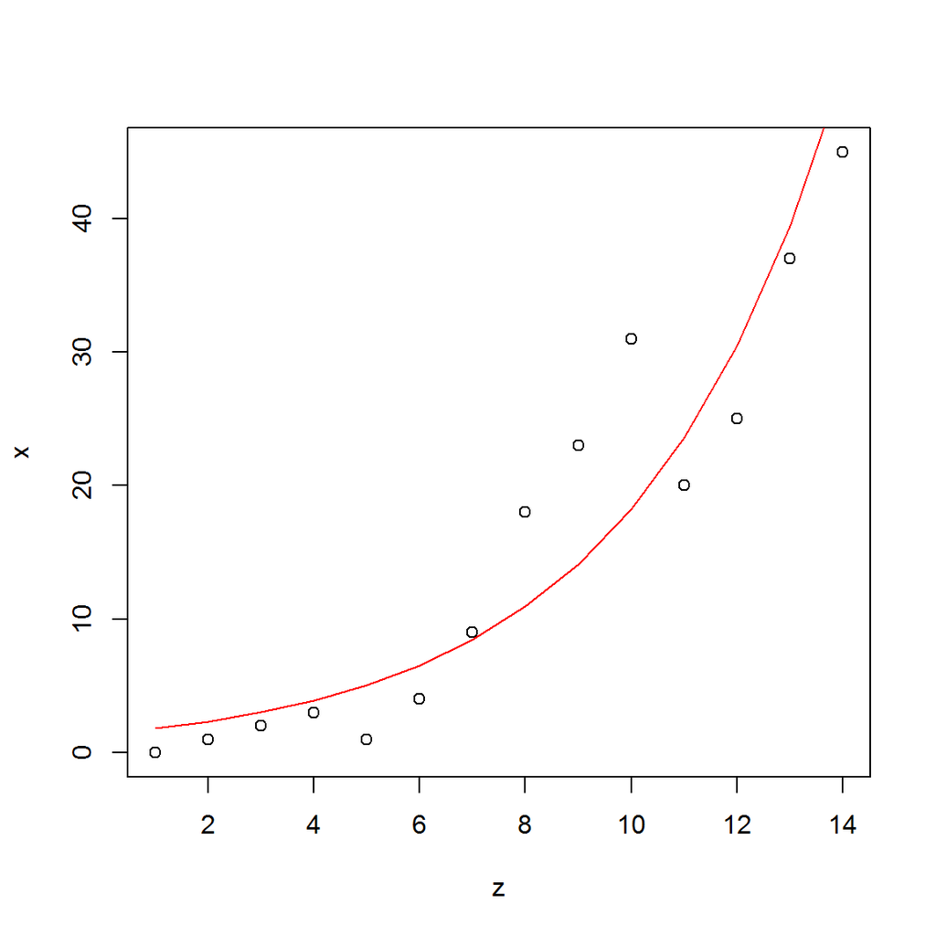

```r
lines(z,exp(theta[1]+theta[2]*z),col="red")
```